# Financial Data Science for Retail Investors

EC0 4051 Financial Econometrics

John, Henry Bowers, Luis, Jeffery

2022-04-13

## Introduction - John Renzo

In the past couple of years, we’ve seen what retail investors are capable of when it comes to changing market behavior. Currently, retail investors have resources that give them an advantage more than they ever did prior. With the importance of financial data science, retail investors now have better access to analyzing raw data to make decisive conclusions. Retail investors can now better assess risk management and learning the skills to code finance will then give them the opportunity to capitalize on their earnings as well as build higher quality models to give them a better and stronger competitive position. Retail investors who indulge in financial data science will be better off understanding and gaining benefits from the modern portfolio theory which gives them the knowledge of having a diverse portfolio that reduces volatility and will also have a better understanding of the importance of the efficient frontier in the MPT that will grant them the ability to get the highest level of return for the lowest level of risk.

## Investment Data Analytics - Henry Bowers

Without any doubt having a strong understanding of fundamentals when it comes to stock picking is extremely important. What is also just as important is understanding data analytics for investment decision-making. Once an investor has decided which securities they want to include in their portfolio, depending on the risk levels their next step will be calculating the returns of the assets and the risk levels to determine the amount of asset allocation for their portfolio should have. Programming in R is amazingly beneficial for this because of the financial libraries. Such Libraries I will be discussing are the usefulness of Quantmod, Performance Analytics, Portfolio Analytics, and Tidyquant.

Quantmod - The quantmod package for R is designed to assist the quantitative trader in developing, testing, and deploying statistically based trading models. quantmod makes modeling easier by removing the repetitive workflow issues surrounding data management, modeling interfaces, and performance analysis.

Performance analytics - PerformanceAnalytics provides an R package of econometric functions for performance and risk analysis of financial instruments or portfolios. This package aims to aid practitioners and researchers in using the latest research for analysis of both normally and non-normally distributed return streams.

Portfolio Analytics - PortfolioAnalytics is an R package to provide numerical solutions for portfolio problems with complex constraints and objective sets. The goal of the package is to aid practitioners and researchers in solving portfolio optimization problems with complex constraints and objectives that mirror real-world applications.

Tidyquant - tidyquant integrates the best resources for collecting and analyzing financial data, zoo, xts, quantmod, and TTR, with the tidy data infrastructure of the tidyverse allowing for seamless interaction between each. You can now perform complete financial analyses in the tidyverse.

### Portfolio Construction

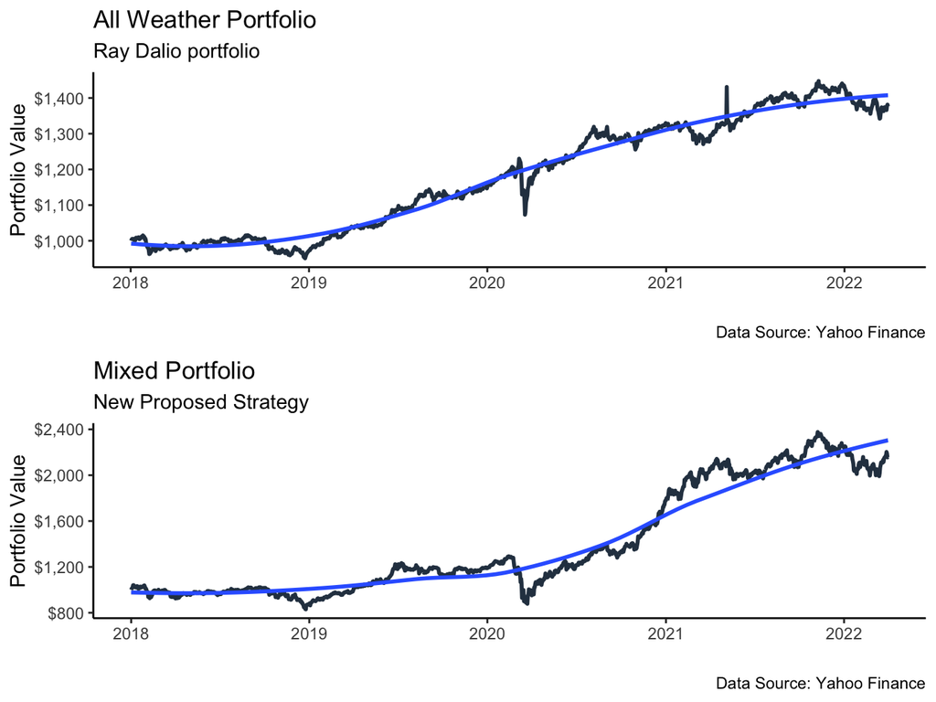

```r
###############################################################################################
##                                The All Weather Portfolio                                 ##
###############################################################################################
AWP_tickers = c("VTI", "VGLT", "VGIT", "IAU", "PDBC")

AWP_weights = c(0.30, 0.40, 0.15, 0.08, 0.07)


# getting price data
AWP_price_data <- tq_get(AWP_tickers,
                   from = '2018-01-01',
                   to = '2022-04-01',
                   get = 'stock.prices')

# asset returns
AWP_ret_data <- AWP_price_data %>%
  group_by(symbol) %>%
  tq_transmute(select = adjusted,
               mutate_fun = periodReturn,
               period = "daily",
               col_rename = "AWP_ret")


# AWP portfolio value returns
AWP_Value <- AWP_ret_data %>%
  tq_portfolio(assets_col = symbol,
               returns_col = AWP_ret,
               weights = AWP_weights,
               col_rename = 'AWP_growth',
               wealth.index = TRUE,
               rebalance = "years") %>%
  mutate(AWP_growth = AWP_growth * 1000)


plot_1 <- AWP_Value %>%
  ggplot(aes(x = date, y = AWP_growth)) +
  geom_line(size = 1, color = palette_light()[[1]]) +
  labs(title = "All Weather Portfolio",
       subtitle = "Ray Dalio portfolio",
       caption = "Data Source: Yahoo Finance",
       x = "", y = "Portfolio Value") +
  geom_smooth(method = "loess") +
  theme_classic() +
  scale_color_tq() +
  scale_y_continuous(labels = scales::dollar)

###############################################################################################
##                                Mixed Portfolio Strategy                                 ##
###############################################################################################

Mixed_tickers = c("VTI", "BTC-USD", "GLD")

Mixed_weights = c(0.80, 0.10, 0.10)


# getting price data
Mixed_price_data <- tq_get(Mixed_tickers,
                   from = '2018-01-01',
                   to = '2022-04-01',
                   get = 'stock.prices')

# asset returns
Mixed_ret_data <- Mixed_price_data %>%
  group_by(symbol) %>%
  tq_transmute(select = adjusted,
               mutate_fun = periodReturn,
               period = "daily",
               col_rename = "Mixed_ret")

# Mixed portfolio value returns
Mixed_Value <- Mixed_ret_data %>%
  tq_portfolio(assets_col = symbol,
               returns_col = Mixed_ret,
               weights = Mixed_weights,
               col_rename = 'Mixed_growth',
               wealth.index = TRUE,
               rebalance = "years") %>%
  mutate(Mixed_growth = Mixed_growth * 1000)


plot_2 <- Mixed_Value %>%
  ggplot(aes(x = date, y = Mixed_growth)) +
  geom_line(size = 1, color = palette_light()[[1]]) +
  labs(title = "Mixed Portfolio",
       subtitle = "New Proposed Strategy",
       caption = "Data Source: Yahoo Finance",
       x = "", y = "Portfolio Value") +
  geom_smooth(method = "loess") +
  theme_classic() +
  scale_color_tq() +
  scale_y_continuous(labels = scales::dollar)


grid.arrange(plot_1, plot_2, ncol=1)
```

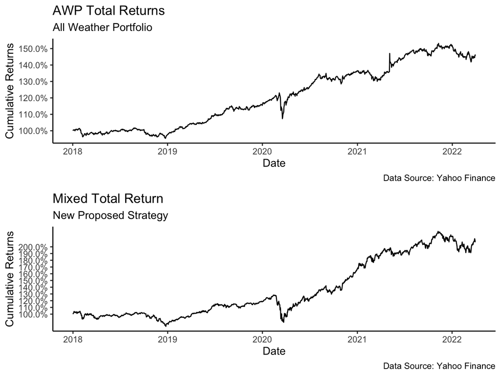

```r
###############################################
## cummulative returns of the AWP portfolio  ##
###############################################
AWP_Cumm_ret <- AWP_ret_data %>%
  tq_portfolio(assets_col = symbol,
               returns_col = AWP_ret,
               weights = AWP_weights,
               col_rename = 'AWP_Cumm_ret',
               geometric = FALSE,
               rebalance = "years")



plot_3 <- AWP_Cumm_ret %>%
  mutate(cr = cumprod(1 + AWP_Cumm_ret)) %>%
  ggplot(aes(x = date, y = cr)) +
  geom_line() +
  labs(x = 'Date',
       y = 'Cumulative Returns',
       title = 'AWP Total Returns',
       subtitle = "All Weather Portfolio",
       caption = "Data Source: Yahoo Finance") +
  theme_classic() +
  scale_y_continuous(breaks = seq(1,2,0.1),
                     labels = scales::percent) +
  scale_x_date(date_breaks = 'year',
               date_labels = '%Y')


###################################################
## Cumulative returns of the Mixture portfolio  ##
##################################################


Mixed_Cumm_ret <- Mixed_ret_data %>%
  tq_portfolio(assets_col = symbol,
               returns_col = Mixed_ret,
               weights = Mixed_weights,
               col_rename = 'Mixed_Cumm_ret',
               geometric = FALSE,
               rebalance = "years")


plot_4 <- Mixed_Cumm_ret %>%
  mutate(cr = cumprod(1 + Mixed_Cumm_ret)) %>%
  ggplot(aes(x = date, y = cr)) +
  geom_line() +
  labs(x = 'Date',
       y = 'Cumulative Returns',
       title = 'Mixed Total Return',
       subtitle = "New Proposed Strategy",
       caption = "Data Source: Yahoo Finance") +
  theme_classic() +
  scale_y_continuous(breaks = seq(1,2,0.1),
                     labels = scales::percent) +
  scale_x_date(date_breaks = 'year',
               date_labels = '%Y')



grid.arrange(plot_3, plot_4, ncol=1)
```

Thus, we can take note, that from 2018 until now, the mixed portfolio has achieved a larger return for its investment compared to investing in the All-Weather Portfolio. This is mainly because, in the past 5 years, bitcoin has increasingly become more popular amongst investors, driving more people to buy the coin since more people see the usefulness of a global universal currency.

### Portfolio Optimization

Portfolio Optimization is a very intense ongoing challenge within the finance industry. Conducting an optimization, you can set many objectives or constraints for the optimization solver, Using the PortfolioAnalytics package in R we could create optimized portfolios within different types of solvers. In this example of optimization, I will be showcasing the random optimization solver. The random solver allows the analyst to create hundreds or even thousands of portfolios generated by the constraints and objectives. I will be taking the mixed portfolio constructed earlier and optimizing that and then back-test the performance of the optimization against the All-Weather Portfolio. constraints are used to make sure the portfolio allocations do not go above 100% and could be used to set a minimum or maximum of weight allocations and a target return for the portfolio. on the other hand, objectives are used to solve, for example, to maximize portfolio return, and minimize portfolio variance. hence the Minimum Variance Portfolio. We could go more in-depth than that by setting a risk budget for the portfolio by having a minimum and maximum portfolio risk based on the investor’s risk preference. Could even set an objective of the portfolio to minimize Value at risk and expected shortfall. Value at Risk in finance represents the percentage value the portfolio is at risk of losing, meanwhile expected shortfall based on historical performance could potentially tell how much the portfolio could lose in a short time frame.

### Portfolio Backtesting

Back-testing portfolio optimization is used to test the performance of a strategy and to test how the portfolio performed against an underlying benchmark. Performing back-test gives visual and statistical evidence for investors to make informed investment decisions. The Following shows the backtest of the portfolio with a periodic rebalance of once a year. With the Portfolio Analytics package, you could rebalance portfolios on a yearly, daily, and quarterly basis. In this example since we will be a focus on a long-only portfolio, we will be rebalancing only once a year.

```r
Mixed_tickers = c("VTI", "BTC-USD", "GLD")

# getting price data
Mixed_price_data <- tq_get(Mixed_tickers,
                   from = '2018-01-01',
                   to = '2022-04-01',
                   get = 'stock.prices')

# asset returns
Mixed_ret_data <- Mixed_price_data %>%
  group_by(symbol) %>%
  tq_transmute(select = adjusted,
               mutate_fun = periodReturn,
               period = "daily",
               col_rename = "Mixed_ret",
               type = "log")


# turns data into an xts object
Mixed_Port_xts <- Mixed_ret_data %>%
  spread(symbol, value = Mixed_ret) %>%
  tk_xts()


port_spec <- portfolio.spec(assets = colnames(Mixed_Port_xts))


port_spec <- add.constraint(portfolio = port_spec, type = "weight_Sum", min_sum = 0.99, max_sum = 1.01) # Weight sum constraint such that the weights sum to 1
port_spec <- add.constraint(portfolio = port_spec, type = "box", min = 0.15, max = 0.45) # box constraint, minimum and maximum allocations



port_spec <- add.objective(portfolio = port_spec, type = "return", name = "mean") # Add an objective to maximize portfolio mean return
port_spec <- add.objective(portfolio = port_spec, type = "risk", name = "StdDev") # Add a risk objective to minimize portfolio standard deviation
port_spec <- add.objective(portfolio = port_spec, type = "risk_budget", name = "StdDev", min_prisk = 0.05, max_prisk = 0.10) # Add a risk budget objective
port_spec <- add.objective(portfolio= port_spec, type='risk', name='var') # Minimizing Value at risk
port_spec <- add.objective(portfolio=port_spec, type='risk', name='es') # minimizing Expected shortfall



rp <- random_portfolios(port_spec, 1000, "simplex")

opt_rebal <- optimize.portfolio.rebalancing(R = Mixed_Port_xts, portfolio = port_spec,
                                            optimize_method = "random", rp = rp,
                                            trace = TRUE, rebalance_on = "years", training_period = 1, rolling_window = 10)
print(opt_rebal)
```

```
PortfolioAnalytics Optimization with Rebalancing

Call:
optimize.portfolio.rebalancing(R = Mixed_Port_xts, portfolio = port_spec,
    optimize_method = "random", trace = TRUE, rp = rp, rebalance_on = "years",
    training_period = 1, rolling_window = 10)

Number of rebalancing dates:  5
First rebalance date:
[1] "2018-12-31"
Last rebalance date:
[1] "2022-04-01"

Annualized Portfolio Rebalancing Return:
[1] 0.1825228

Annualized Portfolio Standard Deviation:
[1] 0.2084381
```

```r
round(extractWeights(opt_rebal), digits = 2)
```

```
           BTC-USD  GLD  VTI
2018-12-31    0.22 0.39 0.39
2019-12-31    0.22 0.39 0.39
2020-12-31    0.22 0.39 0.39
2021-12-31    0.22 0.39 0.39
2022-04-01    0.22 0.39 0.39
```

```r
Rebal_weights <- extractWeights(opt_rebal)


Mixed_port_rets <- na.omit(Return.portfolio(Mixed_Port_xts, Rebal_weights))

colnames(Mixed_port_rets) <- "Mixed Portfolio"


AWP_xts <- AWP_ret_data %>%
  spread(symbol, value = AWP_ret) %>%
  tk_xts()

AWP_weights = c(0.30, 0.40, 0.15, 0.08, 0.07)


AWP_port_rets <- na.omit(Return.portfolio(AWP_xts, AWP_weights, rebalance = "years"))

colnames(AWP_port_rets) <- "All Weather Portfolio"

###############################################
##                 Benchmark data            ##
###############################################

getSymbols("SPY", from = "2018-1-1", to = "2022-4-1")
```

```
[1] "SPY"
```

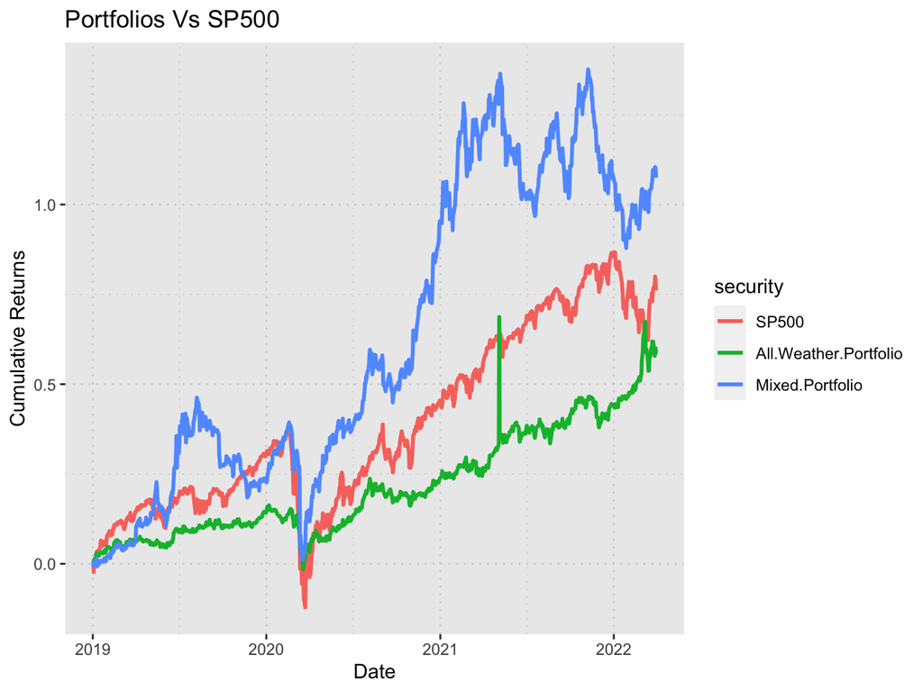

```r
SP500_rets <- na.omit(Ad(Return.calculate(xts(SPY), "log")))

colnames(SP500_rets) <- "SP500"

ports_SP500 <- na.omit(cbind(SP500_rets, AWP_port_rets, Mixed_port_rets))

chart.CumReturns(ports_SP500, plot.engine = "ggplot2", xlab = "Date", ylab = "Cumulative Returns", main = "Portfolios Vs SP500")
```

```r
table.AnnualizedReturns(ports_SP500, Rf = 0.0272/252, digits = 2)
```

```
                             SP500 All.Weather.Portfolio Mixed.Portfolio
Annualized Return             0.19                  0.15            0.25
Annualized Std Dev            0.22                  0.21            0.23
Annualized Sharpe (Rf=2.72%)  0.72                  0.57            0.93
```

### Portfolio Statistics

In statistics, we learned about linear regression models and their use of testing correlations between variables. For finance, a linear regression model is often used to calculate betas the slope and alpha the intercept. Beta is the measurement of systematic risk for the portfolio, if a portfolio has a beta of 1.02 then that represents every 1% move in the underlying benchmark, the portfolio either decreases or increases by 1.02%. This also represents that the closer the beta is to 1 the more correlated returns will be to the benchmark. Alpha on the other hand represents the amount an investment has outperformed or underperformed a benchmark. I will be using the SP500 as the benchmark to test portfolios correlations.

```r
rets <- na.omit(cbind(Mixed_port_rets, AWP_port_rets))

table.CAPM(rets, SP500_rets)
```

```
                    Mixed.Portfolio to SP500 All.Weather.Portfolio to SP500
Alpha                                 0.0005                         0.0005
Beta                                  0.5844                         0.1519
Beta+                                 0.4868                         0.0174
Beta-                                 0.6496                         0.2142
R-squared                             0.2998                         0.0247
Annualized Alpha                      0.1464                         0.1432
Correlation                           0.5475                         0.1570
Correlation p-value                   0.0000                         0.0000
Tracking Error                        0.3328                         0.3090
Active Premium                        0.0616                        -0.0377
Information Ratio                     0.1852                        -0.1219
Treynor Ratio                         0.4308                         1.0039
```

```r
table.Correlation(rets, SP500_rets)
```

```
                               Correlation      p-value   Lower CI  Upper CI
Mixed.Portfolio to SP500         0.5475261 3.041859e-65 0.49768853 0.5937602
All.Weather.Portfolio to SP500   0.1570195 6.338199e-06 0.08947696 0.2231244
```

```r
table.DownsideRisk(rets, ci = 0.95, scale = 252, MAR = 0.10/252, p = 0.95, Rf = 0.0272/252)
```

```
                              Mixed.Portfolio All.Weather.Portfolio
Semi Deviation                         0.0113                0.0087
Gain Deviation                         0.0091                0.0126
Loss Deviation                         0.0128                0.0119
Downside Deviation (MAR=10%)           0.0111                0.0087
Downside Deviation (Rf=2.72%)          0.0109                0.0086
Downside Deviation (0%)                0.0109                0.0085
Maximum Drawdown                       0.3092                0.2086
Historical VaR (95%)                  -0.0203               -0.0101
Historical ES (95%)                   -0.0348               -0.0213
Modified VaR (95%)                    -0.0242                    NA
Modified ES (95%)                     -0.0765               -0.0016
```